# Project: Wrangle and Analyse Data (WE_RATE_DOGS TWITTER ARCHIVE)

#### Test

```python
twitter_archive_clean.name.value_counts()
```

```
Charlie           11
Lucy              11
Cooper            10
Oliver            10
Penny              9
Tucker             9
Sadie              8
Lola               8
Winston            8
Toby               7
Daisy              7
Bo                 6
Oscar              6
Stanley            6
Jax                6
Bella              6
Bailey             6
Koda               6
Rusty              5
Buddy              5
Dave               5
Scout              5
Milo               5
Bentley            5
Chester            5
Leo                5
Louis              5
Jeffrey            4
Jack               4
Scooter            4
Winnie             4
Bear               4
Jerry              4
Archie             4
Maggie             4
Oakley             4
Chip               4
Boomer             4
Sophie             4
Larry              4
```

[output cut: 877 more lines]

```
Dietrich           1
Divine             1
Tripp              1
Huxley             1
Harvey             1
Bookstore          1
Linus              1
Burt               1
Shiloh             1
Gustav             1
Arlen              1
Lenox              1
Jersey             1
Christoper         1
Name: name, dtype: int64
```

```python
twitter_archive_clean['name'].loc[[2267]]
```

```
2267    Big Jumpy Rat
Name: name, dtype: object
```

#### ISSUE #6

#### Define

Remove the http link using regex

#### Code

```python
# create the regular expression to extract the needed words
twitter_archive_clean.source = twitter_archive_clean.source.str.extract('>([\w\W\s]*)<', expand=True)
```

#### Test

```python
twitter_archive_clean.source.head()
```

```
0    Twitter for iPhone
1    Twitter for iPhone
2    Twitter for iPhone
3    Twitter for iPhone
4    Twitter for iPhone
Name: source, dtype: object
```

#### ISSUE #7

#### Define

Replace the none values with Nan

#### Code

```python
# use replace method to remove the none
twitter_archive_clean['floofer'].replace('None',np.nan,inplace=True)
twitter_archive_clean['doggo'].replace('None',np.nan,inplace=True)
twitter_archive_clean['puppo'].replace('None',np.nan,inplace=True)
twitter_archive_clean['pupper'].replace('None',np.nan,inplace=True)
```

#### Test

```python
twitter_archive_clean.sample(10)
```

|  | tweet_id | timestamp | source | text | expanded_urls | rating_numerator | rating_denominator | name | doggo | floofer | pupper | puppo |
| --- | --- | --- | --- | --- | --- | --- | --- | --- | --- | --- | --- | --- |
| 875 | 761227390836215808 | 2016-08-04 15:48:47 | Twitter for iPhone | This is Albert. He just found out that bees are dying globally at an alarming rate. 10/10 heckin worried af now https://t.co/nhLX27WsDY | https://twitter.com/dog_rates/status/761227390836215808/photo/1 | 10 | 10 | Albert | NaN | NaN | NaN | NaN |
| 295 | 837471256429613056 | 2017-03-03 01:14:41 | Twitter for iPhone | This is Vincent. He's suave as h*ck. Will be your copilot this evening. Claims he doesn't need to look at the directions. 12/10 https://t.co/u51tzXSVi3 | https://twitter.com/dog_rates/status/837471256429613056/photo/1,https://twitter.com/dog_rates/status/837471256429613056/photo/1 | 12 | 10 | Vincent | NaN | NaN | NaN | NaN |
| 12 | 889665388333682689 | 2017-07-25 01:55:32 | Twitter for iPhone | Here's a puppo that seems to be on the fence about something haha no but seriously someone help her. 13/10 https://t.co/BxvuXk0UCm | https://twitter.com/dog_rates/status/889665388333682689/photo/1 | 13 | 10 | NaN | NaN | NaN | NaN | puppo |
| 787 | 774639387460112384 | 2016-09-10 16:03:16 | Twitter for iPhone | This is Sprinkles. He's trapped in light jail. 10/10 would post bail for him https://t.co/4s5Xlijogu | https://twitter.com/dog_rates/status/774639387460112384/photo/1,https://twitter.com/dog_rates/status/774639387460112384/photo/1 | 10 | 10 | Sprinkles | NaN | NaN | NaN | NaN |
| 1859 | 675497103322386432 | 2015-12-12 02:07:14 | Twitter for iPhone | Meet Reggie. He's going for the world record. Must concentrate. Focus up pup. 11/10 we all believe in you Reggie https://t.co/h3AWz4AzuC | https://twitter.com/dog_rates/status/675497103322386432/photo/1 | 11 | 10 | Reggie | NaN | NaN | NaN | NaN |
| 2244 | 667886921285246976 | 2015-11-21 02:07:05 | Twitter for iPhone | This is Erik. He's fucken massive. But also kind. Let's people hug him for free. Looks soft. 11/10 I would hug Erik https://t.co/MT7Q4aDQS1 | https://twitter.com/dog_rates/status/667886921285246976/photo/1 | 11 | 10 | Erik | NaN | NaN | NaN | NaN |
| 1287 | 708356463048204288 | 2016-03-11 18:18:36 | Twitter for iPhone | This is Oliver. That is his castle. He protects it with his life. He's also squishy af. 10/10 would squish softly https://t.co/oSuEGw0BhX | https://twitter.com/dog_rates/status/708356463048204288/photo/1,https://twitter.com/dog_rates/status/708356463048204288/photo/1 | 10 | 10 | Oliver | NaN | NaN | NaN | NaN |
| 783 | 775350846108426240 | 2016-09-12 15:10:21 | Vine - Make a Scene | This is Maximus. A little rain won't stop him. He will persevere. 12/10 innovative af https://t.co/2OmDMAkkou | https://vine.co/v/ijmv0PD0XXD | 12 | 10 | Maximus | NaN | NaN | NaN | NaN |
| 1357 | 703407252292673536 | 2016-02-27 02:32:12 | Twitter for iPhone | This pupper doesn't understand gates. 10/10 so close https://t.co/GUbFF4o6dZ | https://twitter.com/dog_rates/status/703407252292673536/photo/1 | 10 | 10 | NaN | NaN | NaN | pupper | NaN |
| 1846 | 675822767435051008 | 2015-12-12 23:41:18 | Twitter for iPhone | 🎶 HELLO FROM THE OTHER SIIIIIIIIDE 🎶 10/10s https://t.co/GK2HJtkdQk | https://twitter.com/dog_rates/status/675822767435051008/photo/1 | 10 | 10 | NaN | NaN | NaN | NaN | NaN |

#### ISSUE #8

#### Define

Remove the https link using regular expression

#### Code

```python
# use replace method and regular expressions to changed the words not needed
twitter_archive_clean.text =twitter_archive_clean.text.str.replace(r'https?://[^\s<>"]+|www\.[^\s<>"]+', "")
```

#### Test

```python
twitter_archive_clean.sample(5)
```

|  | tweet_id | timestamp | source | text | expanded_urls | rating_numerator | rating_denominator | name | doggo | floofer | pupper | puppo |
| --- | --- | --- | --- | --- | --- | --- | --- | --- | --- | --- | --- | --- |
| 1583 | 687102708889812993 | 2016-01-13 02:43:46 | Twitter for iPhone | Army of water dogs here. None of them know where they're going. Have no real purpose. Aggressive barks. 5/10 for all | https://twitter.com/dog_rates/status/687102708889812993/photo/1 | 5 | 10 | NaN | NaN | NaN | NaN | NaN |
| 1189 | 718246886998687744 | 2016-04-08 01:19:36 | Twitter for iPhone | This is Alexanderson. He's got a weird ass birth mark. Dreadful at fetch. Won't eat kibble. 3/10 wtf @Target | https://twitter.com/dog_rates/status/718246886998687744/photo/1 | 3 | 10 | Alexanderson | NaN | NaN | NaN | NaN |
| 158 | 861005113778896900 | 2017-05-06 23:49:50 | Twitter for iPhone | This is Burt. He thinks your thesis statement is comically underdeveloped. 12/10 intellectual af | https://twitter.com/dog_rates/status/861005113778896900/photo/1 | 12 | 10 | Burt | NaN | NaN | NaN | NaN |
| 383 | 827199976799354881 | 2017-02-02 17:00:17 | Twitter for iPhone | This is Charlie. He wins every game of chess he plays. Won't let opponent pet him until they forfeit. 13/10 you win again Charlie | https://twitter.com/dog_rates/status/827199976799354881/photo/1,https://twitter.com/dog_rates/status/827199976799354881/photo/1,https://twitter.com/dog_rates/status/827199976799354881/photo/1,htt... | 13 | 10 | Charlie | NaN | NaN | NaN | NaN |
| 1786 | 677573743309385728 | 2015-12-17 19:39:03 | Twitter for iPhone | This is Sandy. He's sexually confused. Thinks he's a pigeon. Also an All-American cheese catcher. 10/10 so petable | https://twitter.com/dog_rates/status/677573743309385728/photo/1,https://twitter.com/dog_rates/status/677573743309385728/photo/1 | 10 | 10 | Sandy | NaN | NaN | NaN | NaN |

#### ISSUE #9

#### Define

The zeros issue was rectified when the data type was changed to datetime type

#### Test

```python
twitter_archive_clean.timestamp.head()
```

```
0   2017-08-01 16:23:56
1   2017-08-01 00:17:27
2   2017-07-31 00:18:03
3   2017-07-30 15:58:51
4   2017-07-29 16:00:24
Name: timestamp, dtype: datetime64[ns]
```

#### ISSUE #10

#### Define

For all those records whose rating numerator is either less than or equal to 10 or greater than 10 but has a very high value, check if the text contains any fraction whose denominator is 10. If it does, update the rating_numerator with the numerator value of this fraction.

```python
twitter_archive_clean.rating_numerator.value_counts()
```

```
12      504
10      445
11      432
13      308
9       157
8        98
7        53
14       44
5        36
6        32
3        19
4        15
2        11
1         7
420       2
0         2
20        1
1776      1
27        1
666       1
75        1
24        1
17        1
15        1
182       1
26        1
Name: rating_numerator, dtype: int64
```

#### Code

```python
# write a for loop function for rows whose rating numerator is either less than or equal to 10 OR greater than 10 but has a very high value (consider greater than 14)
for i, row in twitter_archive_clean[(twitter_archive_clean.rating_numerator <= 10) | (twitter_archive_clean.rating_numerator > 14)].iterrows():
    ratings = tokens(row.text)
    for rating in ratings:
        if rating.split('/')[1] == '10':
            n = int(round(float(rating.split('/')[0])))
            if (row.rating_numerator == 10 and n > 10) or (row.rating_numerator != 10 and n >= 10):
                twitter_archive_clean.at[i, 'rating_numerator']= n
                break
```

#### Test

```python
twitter_archive_clean.rating_numerator.value_counts()
```

```
12      505
10      445
11      437
13      310
9       157
8        97
7        53
14       45
5        33
6        32
3        19
4        14
2        10
1         7
0         2
420       2
24        1
15        1
182       1
666       1
1776      1
17        1
20        1
Name: rating_numerator, dtype: int64
```

### IMAGE PREDICTIONS DATASET

#### ISSUE #1

#### Define

Replace the underscore using the str.replace() method and correct the capitilization error with the str.title() method to convert the first letter to uppercase.

#### Code

```python
# use the replace method to remove the underscore and the title method to make the first letter capital letter
image_predictions_clean['p1'] = image_predictions_clean['p1'].str.replace('_', ' ').str.title()
image_predictions_clean['p2'] = image_predictions_clean['p2'].str.replace('_', ' ').str.title()
image_predictions_clean['p3'] = image_predictions_clean['p3'].str.replace('_', ' ').str.title()
```

#### Test

```python
image_predictions_clean.sample(5)
```

[output not shown]

#### ISSUE #2

#### Define

Change the datatype of the tweets_id to object using .astype() method

#### Code

```python
# use th astype method to change the datatype
image_predictions_clean['tweet_id']=image_predictions_clean['tweet_id'].astype(object)
```

#### Test

```python
image_predictions_clean.info()
```

[output not shown]

#### ISSUE #3

#### Define

This will be rectified after combining the three datasets together

#### ISSUE #4

#### Define

Remove the rows of data that contain 3 false in all the thre columns of predictions[p1,p2,p3]

#### Code

```python
#put the false columns in a list and drop it
false_predictions = list(image_predictions_clean.query("p1_dog==False and p2_dog==False and p3_dog == False").index)
image_predictions_clean.drop(index=false_predictions,inplace=True)
```

#### Test

```python
image_predictions_clean.sample(10)
```

[output not shown]

```python
image_predictions_clean.info()
```

[output not shown]

## WERATE DOG_TWEET DATASET

#### ISSUE #1

#### Define

Change the datatype of the date_created to datetime and tweets_id to object using .astype() method

#### Code

```python
# change the datatype of the date created column using the astype method
dog_count_clean['date_created']= dog_count_clean['date_created'].astype('datetime64[ns]')
```

```python
# change the datatype of the tweet id column using the astype method
dog_count_clean['tweet_id']=dog_count_clean['tweet_id'].astype(object)
```

#### Test

```python
dog_count_clean.info()
```

```
<class 'pandas.core.frame.DataFrame'>
RangeIndex: 2186 entries, 0 to 2185
Data columns (total 4 columns):
 #   Column          Non-Null Count  Dtype
---  ------          --------------  -----
 0   tweet_id        2186 non-null   object
 1   date_created    2186 non-null   datetime64[ns]
 2   favorite_count  2186 non-null   int64
 3   retweet_count   2186 non-null   int64
dtypes: datetime64[ns](1), int64(2), object(1)
memory usage: 68.4+ KB
```

#### ISSUE #2

#### Define

This will be rectified when we merge all the datasets together

#### ISSUE #3

#### Define

This error have been corrected when we changed the datatype of the date created column

#### Test

```python
dog_count_clean.head()
```

|  | tweet_id | date_created | favorite_count | retweet_count |
| --- | --- | --- | --- | --- |
| 0 | 892420643555336193 | 2017-08-01 16:23:56 | 33702 | 6976 |
| 1 | 892177421306343426 | 2017-08-01 00:17:27 | 29232 | 5280 |
| 2 | 891815181378084864 | 2017-07-31 00:18:03 | 21975 | 3466 |
| 3 | 891689557279858688 | 2017-07-30 15:58:51 | 36779 | 7190 |
| 4 | 891327558926688256 | 2017-07-29 16:00:24 | 35166 | 7723 |

## TIDINESS ISSUE

#### ISSUE #1

#### Define

Merge all the dog stage columns together as a new column and drop the old columns

#### Code

```python
# add the 4 dog stages columns together into a new column
twitter_archive_clean['dog_stage']= twitter_archive_clean['floofer'].map(str) + twitter_archive_clean['doggo'].map(str) + twitter_archive_clean['puppo'].map(str) + twitter_archive_clean['pupper'].map(str)
```

```python
twitter_archive_clean.dog_stage.value_counts()
```

```
nannannannan          1831
nannannanpupper        224
nandoggonannan          75
nannanpupponan          24
nandoggonanpupper       10
floofernannannan         9
nandoggopupponan         1
flooferdoggonannan       1
Name: dog_stage, dtype: int64
```

```python
# replace the nan
twitter_archive_clean.dog_stage= twitter_archive_clean.dog_stage.str.replace(r'nan','')
```

```python
twitter_archive_clean.dog_stage.value_counts()
```

```
                1831
pupper           224
doggo             75
puppo             24
doggopupper       10
floofer            9
doggopuppo         1
flooferdoggo       1
Name: dog_stage, dtype: int64
```

```python
# change the names of some stages that contain two stages together
twitter_archive_clean['dog_stage'].replace("doggopupper","doggo", inplace=True)
twitter_archive_clean['dog_stage'].replace("flooferdoggo","floofer", inplace=True)
twitter_archive_clean['dog_stage'].replace("doggopuppo","puppo", inplace=True)
```

```python
twitter_archive_clean.dog_stage.value_counts()
```

```
           1831
pupper      224
doggo        85
puppo        25
floofer      10
Name: dog_stage, dtype: int64
```

```python
# change the empty character with null value
twitter_archive_clean['dog_stage'].replace("",np.nan,inplace=True)
```

```python
# capitalize the first letter of the stage name
twitter_archive_clean['dog_stage']=twitter_archive_clean['dog_stage'].str.title()
```

```python
# change the datatype of the dog stage column
twitter_archive_clean['dog_stage']=twitter_archive_clean['dog_stage'].astype('category')
```

```python
# drop the former dog stages columns
twitter_archive_clean.drop(["pupper", "puppo", "doggo", "floofer"],axis=1, inplace =True)
```

#### Test

```python
twitter_archive_clean.info()
```

```
<class 'pandas.core.frame.DataFrame'>
Int64Index: 2175 entries, 0 to 2355
Data columns (total 9 columns):
 #   Column              Non-Null Count  Dtype
---  ------              --------------  -----
 0   tweet_id            2175 non-null   object
 1   timestamp           2175 non-null   datetime64[ns]
 2   source              2175 non-null   object
 3   text                2175 non-null   object
 4   expanded_urls       2117 non-null   object
 5   rating_numerator    2175 non-null   int64
 6   rating_denominator  2175 non-null   int64
 7   name                1392 non-null   object
 8   dog_stage           344 non-null    category
dtypes: category(1), datetime64[ns](1), int64(2), object(5)
memory usage: 219.8+ KB
```

```python
twitter_archive_clean.sample(20)
```

|  | tweet_id | timestamp | source | text | expanded_urls | rating_numerator | rating_denominator | name | dog_stage |
| --- | --- | --- | --- | --- | --- | --- | --- | --- | --- |
| 1837 | 676089483918516224 | 2015-12-13 17:21:08 | Twitter for iPhone | "Yes hello I'ma just snag this here toasted bagel real quick. carry on." 9/10 | https://twitter.com/dog_rates/status/676089483918516224/photo/1 | 9 | 10 | NaN | NaN |
| 489 | 813910438903693312 | 2016-12-28 00:52:25 | Twitter for iPhone | This is Chubbs. He dug a hole and now he's stuck in it. Dang h*ckin doggo. 11/10 would assist | https://twitter.com/dog_rates/status/813910438903693312/photo/1 | 11 | 10 | Chubbs | Doggo |
| 1297 | 707776935007539200 | 2016-03-10 03:55:45 | Twitter for iPhone | This is Sadie. She's a Bohemian Rhapsody. Remarkably portable. Could sneak on roller coasters with (probably). 11/10 | https://twitter.com/dog_rates/status/707776935007539200/photo/1 | 11 | 10 | Sadie | NaN |
| 2046 | 671520732782923777 | 2015-12-01 02:46:33 | Twitter for iPhone | Meet Alejandro. He's an extremely seductive pup. 10/10 | https://twitter.com/dog_rates/status/671520732782923777/photo/1 | 10 | 10 | Alejandro | NaN |
| 70 | 879008229531029506 | 2017-06-25 16:07:47 | Twitter for iPhone | This is Beau. That is Beau's balloon. He takes it everywhere. 13/10 would protect at all costs | https://twitter.com/dog_rates/status/879008229531029506/photo/1 | 13 | 10 | Beau | NaN |
| 317 | 834786237630337024 | 2017-02-23 15:25:23 | Twitter for iPhone | This is Tobi. She is properly fetching her shot. H*ckin nifty af bandana. 13/10 would send fully armed battalion to remind her of my love | https://twitter.com/dog_rates/status/834786237630337024/photo/1 | 13 | 10 | Tobi | NaN |
| 2032 | 671763349865160704 | 2015-12-01 18:50:38 | Twitter for iPhone | Say hello to Mark. He's a good dog. Always ready to go for a walk. Excellent posture. 9/10 keep it up Mark | https://twitter.com/dog_rates/status/671763349865160704/photo/1 | 9 | 10 | Mark | NaN |
| 1924 | 674075285688614912 | 2015-12-08 03:57:26 | Twitter for iPhone | Say hello to Mitch. He thinks that's a hat. Nobody has told him yet. 11/10 please no one tell him | https://twitter.com/dog_rates/status/674075285688614912/photo/1 | 11 | 10 | Mitch | NaN |
| 2294 | 667138269671505920 | 2015-11-19 00:32:12 | Twitter for iPhone | Extremely intelligent dog here. Has learned to walk like human. Even has his own dog. Very impressive 10/10 | https://twitter.com/dog_rates/status/667138269671505920/photo/1 | 10 | 10 | NaN | NaN |
| 882 | 760290219849637889 | 2016-08-02 01:44:48 | Twitter Web Client | This is Rocco. He's doing his best. 13/10 someone help him (IG: rocco_roni) | https://twitter.com/dog_rates/status/760290219849637889/video/1 | 13 | 10 | Rocco | NaN |
| 1021 | 746726898085036033 | 2016-06-25 15:29:00 | Twitter for iPhone | Meet Abby. She's incredibly distracting. Just wants to help steer. Hazardous af. Still 12/10 would pet while driving | https://twitter.com/dog_rates/status/746726898085036033/photo/1 | 12 | 10 | Abby | NaN |
| 636 | 793500921481273345 | 2016-11-01 17:12:16 | Twitter for iPhone | This is Fiona. She's an extremely mediocre copilot. Very distracting. Wink makes up for all the missed turns. 12/10 | https://twitter.com/dog_rates/status/793500921481273345/photo/1,https://twitter.com/dog_rates/status/793500921481273345/photo/1 | 12 | 10 | Fiona | NaN |
| 931 | 754120377874386944 | 2016-07-16 01:08:03 | Twitter for iPhone | When you hear your owner say they need to hatch another egg, but you've already been on 17 walks today. 10/10 | https://twitter.com/dog_rates/status/754120377874386944/photo/1 | 10 | 10 | NaN | NaN |
| 1285 | 708469915515297792 | 2016-03-12 01:49:25 | Twitter for iPhone | This is Bobble. He's a Croatian Galifianakis. Hears everything within 400 miles. 11/10 would snug diligently | https://twitter.com/dog_rates/status/708469915515297792/photo/1 | 11 | 10 | Bobble | NaN |
| 1695 | 681261549936340994 | 2015-12-27 23:53:05 | Twitter for iPhone | Say hello to Panda. He's a Quackadilly Shooster. Not amused by your fake ball throwing motion. 9/10 would hug lots | https://twitter.com/dog_rates/status/681261549936340994/photo/1 | 9 | 10 | Panda | NaN |
| 150 | 863062471531167744 | 2017-05-12 16:05:02 | Twitter for iPhone | Say hello to Quinn. She's quite the goofball. Not even a year old. Confirmed 13/10 but she really needs your help \n\n | https://www.gofundme.com/helpquinny,https://twitter.com/dog_rates/status/863062471531167744/photo/1,https://twitter.com/dog_rates/status/863062471531167744/photo/1,https://twitter.com/dog_rates/s... | 13 | 10 | Quinn | NaN |
| 117 | 870063196459192321 | 2017-05-31 23:43:25 | Twitter for iPhone | Meet Clifford. He's quite large. Also red. Good w kids. Somehow never steps on them. Massive poops very inconvenient. Still 14/10 would ride | https://twitter.com/dog_rates/status/870063196459192321/photo/1,https://twitter.com/dog_rates/status/870063196459192321/photo/1 | 14 | 10 | Clifford | NaN |
| 536 | 807010152071229440 | 2016-12-08 23:53:08 | Twitter for iPhone | This is Lennon. He's a Boopershnoop Pupperdoop. Quite rare. Exceptionally pettable. 12/10 would definitely boop that shnoop | https://twitter.com/dog_rates/status/807010152071229440/photo/1 | 12 | 10 | Lennon | NaN |
| 1235 | 712668654853337088 | 2016-03-23 15:53:42 | Twitter for iPhone | Say hello to Sunny and Roxy. They pull things out of water together. 10/10 for both | https://twitter.com/dog_rates/status/712668654853337088/photo/1,https://twitter.com/dog_rates/status/712668654853337088/photo/1,https://twitter.com/dog_rates/status/712668654853337088/photo/1 | 10 | 10 | Sunny | NaN |
| 2344 | 666071193221509120 | 2015-11-16 01:52:02 | Twitter for iPhone | Here we have a northern speckled Rhododendron. Much sass. Gives 0 fucks. Good tongue. 9/10 would caress sensually | https://twitter.com/dog_rates/status/666071193221509120/photo/1 | 9 | 10 | NaN | NaN |

#### ISSUE #2

#### Define

Select the breed predictions that are true with high prediction confidence and extract into a new breed column then drop the p1,p2 and p3 columns. Correct the errors in the name of the breeds using the str.replace() method

#### Code

```python
# The prediction confidence value is sorted  in descending order in the dataset, p1_conf > p2_conf > p3_conf

# create empty lists to keep our required values for each row in the dataset
breed = []
confidence = []

#  create a function that iterates through prediction columns to find the best prediction which is a breed of dog.
def breed_confidence(row):
    if row.p1_dog == True:
        breed.append(row.p1)
        confidence.append(row.p1_conf)
    elif row.p2_dog == True:
        breed.append(row.p2)
        confidence.append(row.p2_conf)
    elif row.p3_dog == True:
        breed.append(row.p3)
        confidence.append(row.p3_conf)
    else:
        breed.append('Unpredicted')
        confidence.append(0)

# call function using pandas apply by columns
image_predictions_clean.apply(breed_confidence, axis=1)

# add lists created to master dataframe
image_predictions_clean['breed'] = breed
image_predictions_clean['confidence'] = confidence
```

```python
# Drop the uninterested columns
image_predictions_clean.drop(columns=['img_num', 'p1', 'p1_conf', 'p1_dog', 'p2',
       'p2_conf', 'p2_dog', 'p3', 'p3_conf', 'p3_dog'], inplace=True)
```

```python
# Replace '-' with empty space
image_predictions_clean.breed = image_predictions_clean.breed.str.replace('-',' ').str.title()
```

#### Test

```python
image_predictions_clean
```

|  | tweet_id | jpg_url | breed | confidence |
| --- | --- | --- | --- | --- |
| 0 | 666020888022790149 | https://pbs.twimg.com/media/CT4udn0WwAA0aMy.jpg | Welsh Springer Spaniel | 0.465074 |
| 1 | 666029285002620928 | https://pbs.twimg.com/media/CT42GRgUYAA5iDo.jpg | Redbone | 0.506826 |
| 2 | 666033412701032449 | https://pbs.twimg.com/media/CT4521TWwAEvMyu.jpg | German Shepherd | 0.596461 |
| 3 | 666044226329800704 | https://pbs.twimg.com/media/CT5Dr8HUEAA-lEu.jpg | Rhodesian Ridgeback | 0.408143 |
| 4 | 666049248165822465 | https://pbs.twimg.com/media/CT5IQmsXIAAKY4A.jpg | Miniature Pinscher | 0.560311 |
| 5 | 666050758794694657 | https://pbs.twimg.com/media/CT5Jof1WUAEuVxN.jpg | Bernese Mountain Dog | 0.651137 |
| 7 | 666055525042405380 | https://pbs.twimg.com/media/CT5N9tpXIAAifs1.jpg | Chow | 0.692517 |
| 8 | 666057090499244032 | https://pbs.twimg.com/media/CT5PY90WoAAQGLo.jpg | Golden Retriever | 0.007959 |
| 9 | 666058600524156928 | https://pbs.twimg.com/media/CT5Qw94XAAA_2dP.jpg | Miniature Poodle | 0.201493 |
| 10 | 666063827256086533 | https://pbs.twimg.com/media/CT5Vg_wXIAAXfnj.jpg | Golden Retriever | 0.775930 |
| 11 | 666071193221509120 | https://pbs.twimg.com/media/CT5cN_3WEAAlOoZ.jpg | Gordon Setter | 0.503672 |
| 12 | 666073100786774016 | https://pbs.twimg.com/media/CT5d9DZXAAALcwe.jpg | Walker Hound | 0.260857 |
| 13 | 666082916733198337 | https://pbs.twimg.com/media/CT5m4VGWEAAtKc8.jpg | Pug | 0.489814 |
| 14 | 666094000022159362 | https://pbs.twimg.com/media/CT5w9gUW4AAsBNN.jpg | Bloodhound | 0.195217 |
| 15 | 666099513787052032 | https://pbs.twimg.com/media/CT51-JJUEAA6hV8.jpg | Lhasa | 0.582330 |
| 16 | 666102155909144576 | https://pbs.twimg.com/media/CT54YGiWUAEZnoK.jpg | English Setter | 0.298617 |
| 19 | 666273097616637952 | https://pbs.twimg.com/media/CT8T1mtUwAA3aqm.jpg | Italian Greyhound | 0.176053 |
| 20 | 666287406224695296 | https://pbs.twimg.com/media/CT8g3BpUEAAuFjg.jpg | Maltese Dog | 0.857531 |
| 22 | 666337882303524864 | https://pbs.twimg.com/media/CT9OwFIWEAMuRje.jpg | Newfoundland | 0.278407 |
| 23 | 666345417576210432 | https://pbs.twimg.com/media/CT9Vn7PWoAA_ZCM.jpg | Golden Retriever | 0.858744 |
| 24 | 666353288456101888 | https://pbs.twimg.com/media/CT9cx0tUEAAhNN_.jpg | Malamute | 0.336874 |
| 26 | 666373753744588802 | https://pbs.twimg.com/media/CT9vZEYWUAAlZ05.jpg | Soft Coated Wheaten Terrier | 0.326467 |
| 27 | 666396247373291520 | https://pbs.twimg.com/media/CT-D2ZHWIAA3gK1.jpg | Chihuahua | 0.978108 |
| 28 | 666407126856765440 | https://pbs.twimg.com/media/CT-NvwmW4AAugGZ.jpg | Black And Tan Coonhound | 0.529139 |
| 30 | 666418789513326592 | https://pbs.twimg.com/media/CT-YWb7U8AA7QnN.jpg | Toy Terrier | 0.149680 |
| 31 | 666421158376562688 | https://pbs.twimg.com/media/CT-aggCXAAIMfT3.jpg | Blenheim Spaniel | 0.906777 |
| 32 | 666428276349472768 | https://pbs.twimg.com/media/CT-g-0DUwAEQdSn.jpg | Pembroke | 0.371361 |
| 33 | 666430724426358785 | https://pbs.twimg.com/media/CT-jNYqW4AAPi2M.jpg | Irish Terrier | 0.104109 |
| 34 | 666435652385423360 | https://pbs.twimg.com/media/CT-nsTQWEAEkyDn.jpg | Chesapeake Bay Retriever | 0.184130 |
| 35 | 666437273139982337 | https://pbs.twimg.com/media/CT-pKmRWIAAxUWj.jpg | Chihuahua | 0.671853 |

[output cut: 1721 more lines]

```python
image_predictions_clean.info()
```

```
<class 'pandas.core.frame.DataFrame'>
Int64Index: 1751 entries, 0 to 2073
Data columns (total 4 columns):
 #   Column      Non-Null Count  Dtype
---  ------      --------------  -----
 0   tweet_id    1751 non-null   object
 1   jpg_url     1751 non-null   object
 2   breed       1751 non-null   object
 3   confidence  1751 non-null   float64
dtypes: float64(1), object(3)
memory usage: 68.4+ KB
```

#### ISSUE #3

#### Define

Combine the three datasets into one to form a more comprehensive table using the .merge() method

#### Code

```python
# use the inner merging method to combine the datasets and get the table with intersected value
master_data = pd.merge(image_predictions_clean, dog_count_clean, how="inner", on = "tweet_id")
```

```python
master_data.info()
```

```
<class 'pandas.core.frame.DataFrame'>
Int64Index: 1630 entries, 0 to 1629
Data columns (total 7 columns):
 #   Column          Non-Null Count  Dtype
---  ------          --------------  -----
 0   tweet_id        1630 non-null   object
 1   jpg_url         1630 non-null   object
 2   breed           1630 non-null   object
 3   confidence      1630 non-null   float64
 4   date_created    1630 non-null   datetime64[ns]
 5   favorite_count  1630 non-null   int64
 6   retweet_count   1630 non-null   int64
dtypes: datetime64[ns](1), float64(1), int64(2), object(3)
memory usage: 101.9+ KB
```

```python
master_data
```

|  | tweet_id | jpg_url | breed | confidence | date_created | favorite_count | retweet_count |
| --- | --- | --- | --- | --- | --- | --- | --- |
| 0 | 666020888022790149 | https://pbs.twimg.com/media/CT4udn0WwAA0aMy.jpg | Welsh Springer Spaniel | 0.465074 | 2015-11-15 22:32:08 | 2283 | 420 |
| 1 | 666029285002620928 | https://pbs.twimg.com/media/CT42GRgUYAA5iDo.jpg | Redbone | 0.506826 | 2015-11-15 23:05:30 | 112 | 39 |
| 2 | 666033412701032449 | https://pbs.twimg.com/media/CT4521TWwAEvMyu.jpg | German Shepherd | 0.596461 | 2015-11-15 23:21:54 | 100 | 36 |
| 3 | 666044226329800704 | https://pbs.twimg.com/media/CT5Dr8HUEAA-lEu.jpg | Rhodesian Ridgeback | 0.408143 | 2015-11-16 00:04:52 | 245 | 115 |
| 4 | 666049248165822465 | https://pbs.twimg.com/media/CT5IQmsXIAAKY4A.jpg | Miniature Pinscher | 0.560311 | 2015-11-16 00:24:50 | 88 | 36 |
| 5 | 666050758794694657 | https://pbs.twimg.com/media/CT5Jof1WUAEuVxN.jpg | Bernese Mountain Dog | 0.651137 | 2015-11-16 00:30:50 | 115 | 50 |
| 6 | 666055525042405380 | https://pbs.twimg.com/media/CT5N9tpXIAAifs1.jpg | Chow | 0.692517 | 2015-11-16 00:49:46 | 367 | 196 |
| 7 | 666057090499244032 | https://pbs.twimg.com/media/CT5PY90WoAAQGLo.jpg | Golden Retriever | 0.007959 | 2015-11-16 00:55:59 | 247 | 112 |
| 8 | 666058600524156928 | https://pbs.twimg.com/media/CT5Qw94XAAA_2dP.jpg | Miniature Poodle | 0.201493 | 2015-11-16 01:01:59 | 99 | 47 |
| 9 | 666063827256086533 | https://pbs.twimg.com/media/CT5Vg_wXIAAXfnj.jpg | Golden Retriever | 0.775930 | 2015-11-16 01:22:45 | 394 | 180 |
| 10 | 666071193221509120 | https://pbs.twimg.com/media/CT5cN_3WEAAlOoZ.jpg | Gordon Setter | 0.503672 | 2015-11-16 01:52:02 | 127 | 51 |
| 11 | 666073100786774016 | https://pbs.twimg.com/media/CT5d9DZXAAALcwe.jpg | Walker Hound | 0.260857 | 2015-11-16 01:59:36 | 274 | 130 |
| 12 | 666082916733198337 | https://pbs.twimg.com/media/CT5m4VGWEAAtKc8.jpg | Pug | 0.489814 | 2015-11-16 02:38:37 | 92 | 37 |
| 13 | 666094000022159362 | https://pbs.twimg.com/media/CT5w9gUW4AAsBNN.jpg | Bloodhound | 0.195217 | 2015-11-16 03:22:39 | 141 | 63 |
| 14 | 666099513787052032 | https://pbs.twimg.com/media/CT51-JJUEAA6hV8.jpg | Lhasa | 0.582330 | 2015-11-16 03:44:34 | 133 | 53 |
| 15 | 666102155909144576 | https://pbs.twimg.com/media/CT54YGiWUAEZnoK.jpg | English Setter | 0.298617 | 2015-11-16 03:55:04 | 66 | 11 |
| 16 | 666273097616637952 | https://pbs.twimg.com/media/CT8T1mtUwAA3aqm.jpg | Italian Greyhound | 0.176053 | 2015-11-16 15:14:19 | 151 | 66 |
| 17 | 666287406224695296 | https://pbs.twimg.com/media/CT8g3BpUEAAuFjg.jpg | Maltese Dog | 0.857531 | 2015-11-16 16:11:11 | 123 | 56 |
| 18 | 666337882303524864 | https://pbs.twimg.com/media/CT9OwFIWEAMuRje.jpg | Newfoundland | 0.278407 | 2015-11-16 19:31:45 | 168 | 79 |
| 19 | 666345417576210432 | https://pbs.twimg.com/media/CT9Vn7PWoAA_ZCM.jpg | Golden Retriever | 0.858744 | 2015-11-16 20:01:42 | 241 | 122 |
| 20 | 666353288456101888 | https://pbs.twimg.com/media/CT9cx0tUEAAhNN_.jpg | Malamute | 0.336874 | 2015-11-16 20:32:58 | 179 | 56 |
| 21 | 666373753744588802 | https://pbs.twimg.com/media/CT9vZEYWUAAlZ05.jpg | Soft Coated Wheaten Terrier | 0.326467 | 2015-11-16 21:54:18 | 162 | 73 |
| 22 | 666396247373291520 | https://pbs.twimg.com/media/CT-D2ZHWIAA3gK1.jpg | Chihuahua | 0.978108 | 2015-11-16 23:23:41 | 147 | 68 |
| 23 | 666407126856765440 | https://pbs.twimg.com/media/CT-NvwmW4AAugGZ.jpg | Black And Tan Coonhound | 0.529139 | 2015-11-17 00:06:54 | 93 | 30 |
| 24 | 666418789513326592 | https://pbs.twimg.com/media/CT-YWb7U8AA7QnN.jpg | Toy Terrier | 0.149680 | 2015-11-17 00:53:15 | 107 | 39 |
| 25 | 666421158376562688 | https://pbs.twimg.com/media/CT-aggCXAAIMfT3.jpg | Blenheim Spaniel | 0.906777 | 2015-11-17 01:02:40 | 272 | 91 |
| 26 | 666428276349472768 | https://pbs.twimg.com/media/CT-g-0DUwAEQdSn.jpg | Pembroke | 0.371361 | 2015-11-17 01:30:57 | 139 | 67 |
| 27 | 666430724426358785 | https://pbs.twimg.com/media/CT-jNYqW4AAPi2M.jpg | Irish Terrier | 0.104109 | 2015-11-17 01:40:41 | 276 | 160 |
| 28 | 666435652385423360 | https://pbs.twimg.com/media/CT-nsTQWEAEkyDn.jpg | Chesapeake Bay Retriever | 0.184130 | 2015-11-17 02:00:15 | 136 | 41 |
| 29 | 666437273139982337 | https://pbs.twimg.com/media/CT-pKmRWIAAxUWj.jpg | Chihuahua | 0.671853 | 2015-11-17 02:06:42 | 106 | 40 |

[output cut: 1600 more lines]

```python
# # use the inner merging method to combine the datasets and get the table with intersected value
cleaned_dataset = pd.merge(twitter_archive_clean,master_data, how="inner", on = "tweet_id")
```

```python
cleaned_dataset.info()
```

```
<class 'pandas.core.frame.DataFrame'>
Int64Index: 1572 entries, 0 to 1571
Data columns (total 15 columns):
 #   Column              Non-Null Count  Dtype
---  ------              --------------  -----
 0   tweet_id            1572 non-null   object
 1   timestamp           1572 non-null   datetime64[ns]
 2   source              1572 non-null   object
 3   text                1572 non-null   object
 4   expanded_urls       1572 non-null   object
 5   rating_numerator    1572 non-null   int64
 6   rating_denominator  1572 non-null   int64
 7   name                1117 non-null   object
 8   dog_stage           238 non-null    category
 9   jpg_url             1572 non-null   object
 10  breed               1572 non-null   object
 11  confidence          1572 non-null   float64
 12  date_created        1572 non-null   datetime64[ns]
 13  favorite_count      1572 non-null   int64
 14  retweet_count       1572 non-null   int64
dtypes: category(1), datetime64[ns](2), float64(1), int64(4), object(7)
memory usage: 186.0+ KB
```

```python
cleaned_dataset
```

|  | tweet_id | timestamp | source | text | expanded_urls | rating_numerator | rating_denominator | name | dog_stage | jpg_url | breed | confidence | date_created | favorite_count | retweet_count |
| --- | --- | --- | --- | --- | --- | --- | --- | --- | --- | --- | --- | --- | --- | --- | --- |
| 0 | 892177421306343426 | 2017-08-01 00:17:27 | Twitter for iPhone | This is Tilly. She's just checking pup on you. Hopes you're doing ok. If not, she's available for pats, snugs, boops, the whole bit. 13/10 | https://twitter.com/dog_rates/status/892177421306343426/photo/1 | 13 | 10 | Tilly | NaN | https://pbs.twimg.com/media/DGGmoV4XsAAUL6n.jpg | Chihuahua | 0.323581 | 2017-08-01 00:17:27 | 29232 | 5280 |
| 1 | 891815181378084864 | 2017-07-31 00:18:03 | Twitter for iPhone | This is Archie. He is a rare Norwegian Pouncing Corgo. Lives in the tall grass. You never know when one may strike. 12/10 | https://twitter.com/dog_rates/status/891815181378084864/photo/1 | 12 | 10 | Archie | NaN | https://pbs.twimg.com/media/DGBdLU1WsAANxJ9.jpg | Chihuahua | 0.716012 | 2017-07-31 00:18:03 | 21975 | 3466 |
| 2 | 891689557279858688 | 2017-07-30 15:58:51 | Twitter for iPhone | This is Darla. She commenced a snooze mid meal. 13/10 happens to the best of us | https://twitter.com/dog_rates/status/891689557279858688/photo/1 | 13 | 10 | Darla | NaN | https://pbs.twimg.com/media/DF_q7IAWsAEuuN8.jpg | Labrador Retriever | 0.168086 | 2017-07-30 15:58:51 | 36779 | 7190 |
| 3 | 891327558926688256 | 2017-07-29 16:00:24 | Twitter for iPhone | This is Franklin. He would like you to stop calling him "cute." He is a very fierce shark and should be respected as such. 12/10 #BarkWeek | https://twitter.com/dog_rates/status/891327558926688256/photo/1,https://twitter.com/dog_rates/status/891327558926688256/photo/1 | 12 | 10 | Franklin | NaN | https://pbs.twimg.com/media/DF6hr6BUMAAzZgT.jpg | Basset | 0.555712 | 2017-07-29 16:00:24 | 35166 | 7723 |
| 4 | 891087950875897856 | 2017-07-29 00:08:17 | Twitter for iPhone | Here we have a majestic great white breaching off South Africa's coast. Absolutely h*ckin breathtaking. 13/10 (IG: tucker_marlo) #BarkWeek | https://twitter.com/dog_rates/status/891087950875897856/photo/1 | 13 | 10 | NaN | NaN | https://pbs.twimg.com/media/DF3HwyEWsAABqE6.jpg | Chesapeake Bay Retriever | 0.425595 | 2017-07-29 00:08:17 | 17736 | 2586 |
| 5 | 890971913173991426 | 2017-07-28 16:27:12 | Twitter for iPhone | Meet Jax. He enjoys ice cream so much he gets nervous around it. 13/10 help Jax enjoy more things by clicking below\n\n | https://gofundme.com/ydvmve-surgery-for-jax,https://twitter.com/dog_rates/status/890971913173991426/photo/1 | 13 | 10 | Jax | NaN | https://pbs.twimg.com/media/DF1eOmZXUAALUcq.jpg | Appenzeller | 0.341703 | 2017-07-28 16:27:12 | 10323 | 1649 |
| 6 | 890729181411237888 | 2017-07-28 00:22:40 | Twitter for iPhone | When you watch your owner call another dog a good boy but then they turn back to you and say you're a great boy. 13/10 | https://twitter.com/dog_rates/status/890729181411237888/photo/1,https://twitter.com/dog_rates/status/890729181411237888/photo/1 | 13 | 10 | NaN | NaN | https://pbs.twimg.com/media/DFyBahAVwAAhUTd.jpg | Pomeranian | 0.566142 | 2017-07-28 00:22:40 | 56636 | 15693 |
| 7 | 890609185150312448 | 2017-07-27 16:25:51 | Twitter for iPhone | This is Zoey. She doesn't want to be one of the scary sharks. Just wants to be a snuggly pettable boatpet. 13/10 #BarkWeek | https://twitter.com/dog_rates/status/890609185150312448/photo/1 | 13 | 10 | Zoey | NaN | https://pbs.twimg.com/media/DFwUU__XcAEpyXI.jpg | Irish Terrier | 0.487574 | 2017-07-27 16:25:51 | 24432 | 3605 |
| 8 | 890240255349198849 | 2017-07-26 15:59:51 | Twitter for iPhone | This is Cassie. She is a college pup. Studying international doggo communication and stick theory. 14/10 so elegant much sophisticate | https://twitter.com/dog_rates/status/890240255349198849/photo/1 | 14 | 10 | Cassie | Doggo | https://pbs.twimg.com/media/DFrEyVuW0AAO3t9.jpg | Pembroke | 0.511319 | 2017-07-26 15:59:51 | 27846 | 6078 |
| 9 | 890006608113172480 | 2017-07-26 00:31:25 | Twitter for iPhone | This is Koda. He is a South Australian deckshark. Deceptively deadly. Frighteningly majestic. 13/10 would risk a petting #BarkWeek | https://twitter.com/dog_rates/status/890006608113172480/photo/1,https://twitter.com/dog_rates/status/890006608113172480/photo/1 | 13 | 10 | Koda | NaN | https://pbs.twimg.com/media/DFnwSY4WAAAMliS.jpg | Samoyed | 0.957979 | 2017-07-26 00:31:25 | 26953 | 6119 |
| 10 | 889880896479866881 | 2017-07-25 16:11:53 | Twitter for iPhone | This is Bruno. He is a service shark. Only gets out of the water to assist you. 13/10 terrifyingly good boy | https://twitter.com/dog_rates/status/889880896479866881/photo/1 | 13 | 10 | Bruno | NaN | https://pbs.twimg.com/media/DFl99B1WsAITKsg.jpg | French Bulldog | 0.377417 | 2017-07-25 16:11:53 | 24495 | 4142 |
| 11 | 889665388333682689 | 2017-07-25 01:55:32 | Twitter for iPhone | Here's a puppo that seems to be on the fence about something haha no but seriously someone help her. 13/10 | https://twitter.com/dog_rates/status/889665388333682689/photo/1 | 13 | 10 | NaN | Puppo | https://pbs.twimg.com/media/DFi579UWsAAatzw.jpg | Pembroke | 0.966327 | 2017-07-25 01:55:32 | 41869 | 8309 |
| 12 | 889638837579907072 | 2017-07-25 00:10:02 | Twitter for iPhone | This is Ted. He does his best. Sometimes that's not enough. But it's ok. 12/10 would assist | https://twitter.com/dog_rates/status/889638837579907072/photo/1,https://twitter.com/dog_rates/status/889638837579907072/photo/1 | 12 | 10 | Ted | NaN | https://pbs.twimg.com/media/DFihzFfXsAYGDPR.jpg | French Bulldog | 0.991650 | 2017-07-25 00:10:02 | 23575 | 3702 |
| 13 | 889531135344209921 | 2017-07-24 17:02:04 | Twitter for iPhone | This is Stuart. He's sporting his favorite fanny pack. Secretly filled with bones only. 13/10 puppared puppo #BarkWeek | https://twitter.com/dog_rates/status/889531135344209921/photo/1 | 13 | 10 | Stuart | Puppo | https://pbs.twimg.com/media/DFg_2PVW0AEHN3p.jpg | Golden Retriever | 0.953442 | 2017-07-24 17:02:04 | 13304 | 1874 |
| 14 | 889278841981685760 | 2017-07-24 00:19:32 | Twitter for iPhone | This is Oliver. You're witnessing one of his many brutal attacks. Seems to be playing with his victim. 13/10 fr*ckin frightening #BarkWeek | https://twitter.com/dog_rates/status/889278841981685760/video/1 | 13 | 10 | Oliver | NaN | https://pbs.twimg.com/ext_tw_video_thumb/889278779352338437/pu/img/VlbFB3v8H8VwzVNY.jpg | Whippet | 0.626152 | 2017-07-24 00:19:32 | 22012 | 4426 |
| 15 | 888917238123831296 | 2017-07-23 00:22:39 | Twitter for iPhone | This is Jim. He found a fren. Taught him how to sit like the good boys. 12/10 for both | https://twitter.com/dog_rates/status/888917238123831296/photo/1 | 12 | 10 | Jim | NaN | https://pbs.twimg.com/media/DFYRgsOUQAARGhO.jpg | Golden Retriever | 0.714719 | 2017-07-23 00:22:39 | 25521 | 3746 |
| 16 | 888804989199671297 | 2017-07-22 16:56:37 | Twitter for iPhone | This is Zeke. He has a new stick. Very proud of it. Would like you to throw it for him without taking it. 13/10 would do my best | https://twitter.com/dog_rates/status/888804989199671297/photo/1,https://twitter.com/dog_rates/status/888804989199671297/photo/1 | 13 | 10 | Zeke | NaN | https://pbs.twimg.com/media/DFWra-3VYAA2piG.jpg | Golden Retriever | 0.469760 | 2017-07-22 16:56:37 | 22384 | 3517 |
| 17 | 888554962724278272 | 2017-07-22 00:23:06 | Twitter for iPhone | This is Ralphus. He's powering up. Attempting maximum borkdrive. 13/10 inspirational af | https://twitter.com/dog_rates/status/888554962724278272/photo/1,https://twitter.com/dog_rates/status/888554962724278272/photo/1,https://twitter.com/dog_rates/status/888554962724278272/photo/1,htt... | 13 | 10 | Ralphus | NaN | https://pbs.twimg.com/media/DFTH_O-UQAACu20.jpg | Siberian Husky | 0.700377 | 2017-07-22 00:23:06 | 17252 | 2867 |
| 18 | 888078434458587136 | 2017-07-20 16:49:33 | Twitter for iPhone | This is Gerald. He was just told he didn't get the job he interviewed for. A h*ckin injustice. 12/10 didn't want the job anyway | https://twitter.com/dog_rates/status/888078434458587136/photo/1,https://twitter.com/dog_rates/status/888078434458587136/photo/1 | 12 | 10 | Gerald | NaN | https://pbs.twimg.com/media/DFMWn56WsAAkA7B.jpg | French Bulldog | 0.995026 | 2017-07-20 16:49:33 | 19093 | 2886 |
| 19 | 887705289381826560 | 2017-07-19 16:06:48 | Twitter for iPhone | This is Jeffrey. He has a monopoly on the pool noodles. Currently running a 'boop for two' midweek sale. 13/10 h*ckin strategic | https://twitter.com/dog_rates/status/887705289381826560/photo/1 | 13 | 10 | Jeffrey | NaN | https://pbs.twimg.com/media/DFHDQBbXgAEqY7t.jpg | Basset | 0.821664 | 2017-07-19 16:06:48 | 26529 | 4521 |
| 20 | 887473957103951883 | 2017-07-19 00:47:34 | Twitter for iPhone | This is Canela. She attempted some fancy porch pics. They were unsuccessful. 13/10 someone help her | https://twitter.com/dog_rates/status/887473957103951883/photo/1,https://twitter.com/dog_rates/status/887473957103951883/photo/1 | 13 | 10 | Canela | NaN | https://pbs.twimg.com/media/DFDw2tyUQAAAFke.jpg | Pembroke | 0.809197 | 2017-07-19 00:47:34 | 59970 | 14969 |
| 21 | 887343217045368832 | 2017-07-18 16:08:03 | Twitter for iPhone | You may not have known you needed to see this today. 13/10 please enjoy (IG: emmylouroo) | https://twitter.com/dog_rates/status/887343217045368832/video/1 | 13 | 10 | NaN | NaN | https://pbs.twimg.com/ext_tw_video_thumb/887343120832229379/pu/img/6HSuFrW1lzI_9Mht.jpg | Mexican Hairless | 0.330741 | 2017-07-18 16:08:03 | 29480 | 8786 |
| 22 | 887101392804085760 | 2017-07-18 00:07:08 | Twitter for iPhone | This... is a Jubilant Antarctic House Bear. We only rate dogs. Please only send dogs. Thank you... 12/10 would suffocate in floof | https://twitter.com/dog_rates/status/887101392804085760/photo/1 | 12 | 10 | NaN | NaN | https://pbs.twimg.com/media/DE-eAq6UwAA-jaE.jpg | Samoyed | 0.733942 | 2017-07-18 00:07:08 | 26884 | 4972 |
| 23 | 886983233522544640 | 2017-07-17 16:17:36 | Twitter for iPhone | This is Maya. She's very shy. Rarely leaves her cup. 13/10 would find her an environment to thrive in | https://twitter.com/dog_rates/status/886983233522544640/photo/1,https://twitter.com/dog_rates/status/886983233522544640/photo/1 | 13 | 10 | Maya | NaN | https://pbs.twimg.com/media/DE8yicJW0AAAvBJ.jpg | Chihuahua | 0.793469 | 2017-07-17 16:17:36 | 30255 | 6293 |
| 24 | 886736880519319552 | 2017-07-16 23:58:41 | Twitter for iPhone | This is Mingus. He's a wonderful father to his smol pup. Confirmed 13/10, but he needs your help\n\n | https://www.gofundme.com/mingusneedsus,https://twitter.com/dog_rates/status/886736880519319552/photo/1,https://twitter.com/dog_rates/status/886736880519319552/photo/1 | 13 | 10 | Mingus | NaN | https://pbs.twimg.com/media/DE5Se8FXcAAJFx4.jpg | Kuvasz | 0.309706 | 2017-07-16 23:58:41 | 10458 | 2619 |
| 25 | 886366144734445568 | 2017-07-15 23:25:31 | Twitter for iPhone | This is Roscoe. Another pupper fallen victim to spontaneous tongue ejections. Get the BlepiPen immediate. 12/10 deep breaths Roscoe | https://twitter.com/dog_rates/status/886366144734445568/photo/1,https://twitter.com/dog_rates/status/886366144734445568/photo/1 | 12 | 10 | Roscoe | Pupper | https://pbs.twimg.com/media/DE0BTnQUwAApKEH.jpg | French Bulldog | 0.999201 | 2017-07-15 23:25:31 | 18494 | 2613 |
| 26 | 886258384151887873 | 2017-07-15 16:17:19 | Twitter for iPhone | This is Waffles. His doggles are pupside down. Unsure how to fix. 13/10 someone assist Waffles | https://twitter.com/dog_rates/status/886258384151887873/photo/1 | 13 | 10 | Waffles | NaN | https://pbs.twimg.com/media/DEyfTG4UMAE4aE9.jpg | Pug | 0.943575 | 2017-07-15 16:17:19 | 24443 | 5260 |
| 27 | 885984800019947520 | 2017-07-14 22:10:11 | Twitter for iPhone | Viewer discretion advised. This is Jimbo. He will rip ur finger right h*ckin off. Other dog clearly an accessory. 12/10 pls pet with caution | https://twitter.com/dog_rates/status/885984800019947520/photo/1 | 12 | 10 | Jimbo | NaN | https://pbs.twimg.com/media/DEumeWWV0AA-Z61.jpg | Blenheim Spaniel | 0.972494 | 2017-07-14 22:10:11 | 28491 | 5590 |
| 28 | 885528943205470208 | 2017-07-13 15:58:47 | Twitter for iPhone | This is Maisey. She fell asleep mid-excavation. Happens to the best of us. 13/10 would pat noggin approvingly | https://twitter.com/dog_rates/status/885528943205470208/photo/1 | 13 | 10 | Maisey | NaN | https://pbs.twimg.com/media/DEoH3yvXgAAzQtS.jpg | Pug | 0.369275 | 2017-07-13 15:58:47 | 31495 | 5309 |
| 29 | 885167619883638784 | 2017-07-12 16:03:00 | Twitter for iPhone | Here we have a corgi undercover as a malamute. Pawbably doing important investigative work. Zero control over tongue happenings. 13/10 | https://twitter.com/dog_rates/status/885167619883638784/photo/1,https://twitter.com/dog_rates/status/885167619883638784/photo/1,https://twitter.com/dog_rates/status/885167619883638784/photo/1,htt... | 13 | 10 | NaN | NaN | https://pbs.twimg.com/media/DEi_N9qXYAAgEEw.jpg | Malamute | 0.812482 | 2017-07-12 16:03:00 | 19188 | 3654 |

[output cut: 1542 more lines]

## Observation

1. The timestamp and date_created columns have the same values,duplicated columns are not needed. Date_created column will be dropped.
2. Some column names have to be renamed for clearer description.

#### Define

The date_created column will be dropped using the .drop() method and the columns will be renamed appropriately using .rename() method

#### Code

```python
# use the drop metod to remove the date created column
cleaned_dataset.drop('date_created',axis=1,inplace=True)
```

```python
#use the rename method to change the names of some columns for proper description
cleaned_dataset.rename(columns={'name':'dog_name','breed':'predicted_dog_breed','confidence':'prediction_confidence'},inplace=True)
```

#### Test

```python
cleaned_dataset.head()
```

|  | tweet_id | timestamp | source | text | expanded_urls | rating_numerator | rating_denominator | dog_name | dog_stage | jpg_url | predicted_dog_breed | prediction_confidence | favorite_count | retweet_count |
| --- | --- | --- | --- | --- | --- | --- | --- | --- | --- | --- | --- | --- | --- | --- |
| 0 | 892177421306343426 | 2017-08-01 00:17:27 | Twitter for iPhone | This is Tilly. She's just checking pup on you. Hopes you're doing ok. If not, she's available for pats, snugs, boops, the whole bit. 13/10 | https://twitter.com/dog_rates/status/892177421306343426/photo/1 | 13 | 10 | Tilly | NaN | https://pbs.twimg.com/media/DGGmoV4XsAAUL6n.jpg | Chihuahua | 0.323581 | 29232 | 5280 |
| 1 | 891815181378084864 | 2017-07-31 00:18:03 | Twitter for iPhone | This is Archie. He is a rare Norwegian Pouncing Corgo. Lives in the tall grass. You never know when one may strike. 12/10 | https://twitter.com/dog_rates/status/891815181378084864/photo/1 | 12 | 10 | Archie | NaN | https://pbs.twimg.com/media/DGBdLU1WsAANxJ9.jpg | Chihuahua | 0.716012 | 21975 | 3466 |
| 2 | 891689557279858688 | 2017-07-30 15:58:51 | Twitter for iPhone | This is Darla. She commenced a snooze mid meal. 13/10 happens to the best of us | https://twitter.com/dog_rates/status/891689557279858688/photo/1 | 13 | 10 | Darla | NaN | https://pbs.twimg.com/media/DF_q7IAWsAEuuN8.jpg | Labrador Retriever | 0.168086 | 36779 | 7190 |
| 3 | 891327558926688256 | 2017-07-29 16:00:24 | Twitter for iPhone | This is Franklin. He would like you to stop calling him "cute." He is a very fierce shark and should be respected as such. 12/10 #BarkWeek | https://twitter.com/dog_rates/status/891327558926688256/photo/1,https://twitter.com/dog_rates/status/891327558926688256/photo/1 | 12 | 10 | Franklin | NaN | https://pbs.twimg.com/media/DF6hr6BUMAAzZgT.jpg | Basset | 0.555712 | 35166 | 7723 |
| 4 | 891087950875897856 | 2017-07-29 00:08:17 | Twitter for iPhone | Here we have a majestic great white breaching off South Africa's coast. Absolutely h*ckin breathtaking. 13/10 (IG: tucker_marlo) #BarkWeek | https://twitter.com/dog_rates/status/891087950875897856/photo/1 | 13 | 10 | NaN | NaN | https://pbs.twimg.com/media/DF3HwyEWsAABqE6.jpg | Chesapeake Bay Retriever | 0.425595 | 17736 | 2586 |

```python
cleaned_dataset.info()
```

```
<class 'pandas.core.frame.DataFrame'>
Int64Index: 1572 entries, 0 to 1571
Data columns (total 14 columns):
 #   Column                 Non-Null Count  Dtype
---  ------                 --------------  -----
 0   tweet_id               1572 non-null   object
 1   timestamp              1572 non-null   datetime64[ns]
 2   source                 1572 non-null   object
 3   text                   1572 non-null   object
 4   expanded_urls          1572 non-null   object
 5   rating_numerator       1572 non-null   int64
 6   rating_denominator     1572 non-null   int64
 7   dog_name               1117 non-null   object
 8   dog_stage              238 non-null    category
 9   jpg_url                1572 non-null   object
 10  predicted_dog_breed    1572 non-null   object
 11  prediction_confidence  1572 non-null   float64
 12  favorite_count         1572 non-null   int64
 13  retweet_count          1572 non-null   int64
dtypes: category(1), datetime64[ns](1), float64(1), int64(4), object(7)
memory usage: 173.7+ KB
```

# STORING DATA

#### Define

Storing the gathered,assessed and cleaned master DataFrame in a CSV file named twitter_archive_master.csv.

#### Code

```python
# use the ro_csv method to save the dataset to a new name
cleaned_dataset.to_csv('twitter_archive_master.csv',index=False)
```

#### Test

```python
twitter_archive_master= pd.read_csv('twitter_archive_master.csv')
twitter_archive_master.head()
```

|  | tweet_id | timestamp | source | text | expanded_urls | rating_numerator | rating_denominator | dog_name | dog_stage | jpg_url | predicted_dog_breed | prediction_confidence | favorite_count | retweet_count |
| --- | --- | --- | --- | --- | --- | --- | --- | --- | --- | --- | --- | --- | --- | --- |
| 0 | 892177421306343426 | 2017-08-01 00:17:27 | Twitter for iPhone | This is Tilly. She's just checking pup on you.... | https://twitter.com/dog_rates/status/892177421... | 13 | 10 | Tilly | NaN | https://pbs.twimg.com/media/DGGmoV4XsAAUL6n.jpg | Chihuahua | 0.323581 | 29232 | 5280 |
| 1 | 891815181378084864 | 2017-07-31 00:18:03 | Twitter for iPhone | This is Archie. He is a rare Norwegian Pouncin... | https://twitter.com/dog_rates/status/891815181... | 12 | 10 | Archie | NaN | https://pbs.twimg.com/media/DGBdLU1WsAANxJ9.jpg | Chihuahua | 0.716012 | 21975 | 3466 |
| 2 | 891689557279858688 | 2017-07-30 15:58:51 | Twitter for iPhone | This is Darla. She commenced a snooze mid meal... | https://twitter.com/dog_rates/status/891689557... | 13 | 10 | Darla | NaN | https://pbs.twimg.com/media/DF_q7IAWsAEuuN8.jpg | Labrador Retriever | 0.168086 | 36779 | 7190 |
| 3 | 891327558926688256 | 2017-07-29 16:00:24 | Twitter for iPhone | This is Franklin. He would like you to stop ca... | https://twitter.com/dog_rates/status/891327558... | 12 | 10 | Franklin | NaN | https://pbs.twimg.com/media/DF6hr6BUMAAzZgT.jpg | Basset | 0.555712 | 35166 | 7723 |
| 4 | 891087950875897856 | 2017-07-29 00:08:17 | Twitter for iPhone | Here we have a majestic great white breaching ... | https://twitter.com/dog_rates/status/891087950... | 13 | 10 | NaN | NaN | https://pbs.twimg.com/media/DF3HwyEWsAABqE6.jpg | Chesapeake Bay Retriever | 0.425595 | 17736 | 2586 |

```python
twitter_archive_master.info()
```

```
<class 'pandas.core.frame.DataFrame'>
RangeIndex: 1572 entries, 0 to 1571
Data columns (total 14 columns):
 #   Column                 Non-Null Count  Dtype
---  ------                 --------------  -----
 0   tweet_id               1572 non-null   int64
 1   timestamp              1572 non-null   object
 2   source                 1572 non-null   object
 3   text                   1572 non-null   object
 4   expanded_urls          1572 non-null   object
 5   rating_numerator       1572 non-null   int64
 6   rating_denominator     1572 non-null   int64
 7   dog_name               1117 non-null   object
 8   dog_stage              238 non-null    object
 9   jpg_url                1572 non-null   object
 10  predicted_dog_breed    1572 non-null   object
 11  prediction_confidence  1572 non-null   float64
 12  favorite_count         1572 non-null   int64
 13  retweet_count          1572 non-null   int64
dtypes: float64(1), int64(5), object(8)
memory usage: 172.1+ KB
```

# ANALYZING AND VISUALIZING DATA

#### With the dataset formerly load, view it to check for insights

```python
twitter_archive_master.sample(20)
```

|  | tweet_id | timestamp | source | text | expanded_urls | rating_numerator | rating_denominator | dog_name | dog_stage | jpg_url | predicted_dog_breed | prediction_confidence | favorite_count | retweet_count |
| --- | --- | --- | --- | --- | --- | --- | --- | --- | --- | --- | --- | --- | --- | --- |
| 1002 | 686606069955735556 | 2016-01-11 17:50:18 | Twitter for iPhone | Meet Horace. He was practicing his levitation, minding his own business when a rogue tennis ball spooked him. 10/10 | https://twitter.com/dog_rates/status/686606069955735556/photo/1 | 10 | 10 | Horace | NaN | https://pbs.twimg.com/media/CYdQktMWsAEI29_.jpg | Labrador Retriever | 0.320012 | 1749 | 490 |
| 907 | 706166467411222528 | 2016-03-05 17:16:20 | Twitter for iPhone | This is Dexter. He's a shy pup. Doesn't bark much. Dreadful fetcher. Has rare sun allergy. 7/10 still petable | https://twitter.com/dog_rates/status/706166467411222528/photo/1 | 7 | 10 | Dexter | NaN | https://pbs.twimg.com/media/CczOp_OWoAAo5zR.jpg | Samoyed | 0.430418 | 4712 | 1447 |
| 146 | 851591660324737024 | 2017-04-11 00:24:08 | Twitter for iPhone | Oh jeez u did me quite the spook little fella. We normally don't rate triceratops but this one seems suspiciously good. 11/10 would pet well | https://twitter.com/dog_rates/status/851591660324737024/photo/1 | 11 | 10 | NaN | NaN | https://pbs.twimg.com/media/C9F2FG5WAAAJ0iN.jpg | Cardigan | 0.394507 | 14924 | 3123 |
| 510 | 773985732834758656 | 2016-09-08 20:45:53 | Twitter for iPhone | Meet Winnie. She just made awkward eye contact with the driver beside her. Poor pupper panicked. 11/10 would comfort | https://twitter.com/dog_rates/status/773985732834758656/photo/1,https://twitter.com/dog_rates/status/773985732834758656/photo/1,https://twitter.com/dog_rates/status/773985732834758656/photo/1,htt... | 11 | 10 | Winnie | Pupper | https://pbs.twimg.com/media/Cr2_6R8WAAAUMtc.jpg | Pug | 0.109570 | 10130 | 3576 |
| 1491 | 667793409583771648 | 2015-11-20 19:55:30 | Twitter for iPhone | Dogs only please. Small cows and other non canines will not be tolerated. Sick tattoos tho 8/10 | https://twitter.com/dog_rates/status/667793409583771648/photo/1 | 8 | 10 | NaN | NaN | https://pbs.twimg.com/media/CUR6jqVWsAEgGot.jpg | Dalmatian | 0.535073 | 606 | 286 |
| 501 | 776218204058357768 | 2016-09-15 00:36:55 | Twitter for iPhone | Atlas rolled around in some chalk and now he's a magical rainbow floofer. 13/10 please never take a bath | https://twitter.com/dog_rates/status/776218204058357768/photo/1,https://twitter.com/dog_rates/status/776218204058357768/photo/1,https://twitter.com/dog_rates/status/776218204058357768/photo/1 | 13 | 10 | NaN | Floofer | https://pbs.twimg.com/media/CsWuVEdWcAAqbe9.jpg | Samoyed | 0.940326 | 28004 | 14650 |
| 773 | 724983749226668032 | 2016-04-26 15:29:30 | Twitter for iPhone | This is Fred-Rick. He dabbles in parkour. The elevation gives him power. 12/10 hopefully visiting a mailbox near you | https://twitter.com/dog_rates/status/724983749226668032/photo/1 | 12 | 10 | Fred | NaN | https://pbs.twimg.com/media/Cg-o3w0WgAANXdv.jpg | Golden Retriever | 0.675750 | 3437 | 1166 |
| 215 | 833479644947025920 | 2017-02-20 00:53:27 | Twitter for iPhone | This is Poppy. She just arrived. 13/10 would snug passionately | https://twitter.com/dog_rates/status/833479644947025920/photo/1,https://twitter.com/dog_rates/status/833479644947025920/photo/1,https://twitter.com/dog_rates/status/833479644947025920/photo/1 | 13 | 10 | Poppy | NaN | https://pbs.twimg.com/media/C5EdT4jWEAARv2C.jpg | Golden Retriever | 0.727039 | 13969 | 1882 |
| 274 | 822872901745569793 | 2017-01-21 18:26:02 | Twitter for iPhone | Here's a super supportive puppo participating in the Toronto #WomensMarch today. 13/10 | https://twitter.com/dog_rates/status/822872901745569793/photo/1 | 13 | 10 | NaN | Puppo | https://pbs.twimg.com/media/C2tugXLXgAArJO4.jpg | Lakeland Terrier | 0.196015 | 123635 | 39801 |
| 995 | 687127927494963200 | 2016-01-13 04:23:58 | Twitter for iPhone | Meet Gordon. He's an asshole. 9/10 would still pet | https://twitter.com/dog_rates/status/687127927494963200/photo/1 | 9 | 10 | Gordon | NaN | https://pbs.twimg.com/media/CYkrNIVWcAMswmP.jpg | Pug | 0.178205 | 4967 | 2049 |
| 1472 | 668268907921326080 | 2015-11-22 03:24:58 | Twitter for iPhone | Here we have an Azerbaijani Buttermilk named Guss. He sees a demon baby Hitler behind his owner. 10/10 stays alert | https://twitter.com/dog_rates/status/668268907921326080/photo/1 | 10 | 10 | NaN | NaN | https://pbs.twimg.com/media/CUYrBNQUkAA-zx4.jpg | Pembroke | 0.484830 | 482 | 206 |
| 860 | 709852847387627521 | 2016-03-15 21:24:41 | Twitter for iPhone | *lets out a tiny whimper and then collapses* ...12/10 | https://twitter.com/dog_rates/status/709852847387627521/photo/1,https://twitter.com/dog_rates/status/709852847387627521/photo/1,https://twitter.com/dog_rates/status/709852847387627521/photo/1,htt... | 12 | 10 | NaN | NaN | https://pbs.twimg.com/media/CdnnZhhWAAEAoUc.jpg | Chihuahua | 0.945629 | 3232 | 1089 |
| 1488 | 667832474953625600 | 2015-11-20 22:30:44 | Twitter for iPhone | THE EYES 12/10\n\nI'm sorry. These are supposed to be funny but your dogs are too adorable | https://twitter.com/dog_rates/status/667832474953625600/photo/1 | 12 | 10 | NaN | NaN | https://pbs.twimg.com/media/CUSeGFNW4AAyyHC.jpg | Miniature Pinscher | 0.214200 | 254 | 54 |
| 353 | 808838249661788160 | 2016-12-14 00:57:20 | Twitter for iPhone | This is Ito. He'll be your uber driver tonight. Currently adjusting the mirrors. 13/10 incredibly h*ckin responsible | https://twitter.com/dog_rates/status/808838249661788160/photo/1 | 13 | 10 | Ito | NaN | https://pbs.twimg.com/media/CzmSFlKUAAAQOjP.jpg | Rottweiler | 0.369530 | 9623 | 2857 |
| 64 | 876484053909872640 | 2017-06-18 16:57:37 | Twitter for iPhone | This is Benedict. He wants to thank you for this delightful urban walk. Hopes you know he loves you. 13/10 super duper good boy | https://twitter.com/dog_rates/status/876484053909872640/photo/1 | 13 | 10 | Benedict | NaN | https://pbs.twimg.com/media/DCnll_dUQAAkBdG.jpg | Golden Retriever | 0.874566 | 16513 | 1992 |
| 933 | 692568918515392513 | 2016-01-28 04:44:32 | Twitter for iPhone | This is Chester. He's been guarding this pumpkin since October. Dedicated af. Hat is nifty as hell. 12/10 would snug | https://twitter.com/dog_rates/status/692568918515392513/photo/1,https://twitter.com/dog_rates/status/692568918515392513/photo/1,https://twitter.com/dog_rates/status/692568918515392513/photo/1 | 12 | 10 | Chester | NaN | https://pbs.twimg.com/media/CZx_wV2UMAArgsJ.jpg | Golden Retriever | 0.636845 | 4024 | 1392 |
| 506 | 775085132600442880 | 2016-09-11 21:34:30 | Twitter for iPhone | This is Tucker. He would like a hug. 13/10 someone hug him | https://twitter.com/dog_rates/status/775085132600442880/photo/1 | 13 | 10 | Tucker | NaN | https://pbs.twimg.com/media/CsGnz64WYAEIDHJ.jpg | Chow | 0.316565 | 14587 | 4355 |
| 754 | 728751179681943552 | 2016-05-07 00:59:55 | Twitter for iPhone | This is Flurpson. He can't believe it's not butter. 10/10 | https://twitter.com/dog_rates/status/728751179681943552/photo/1 | 10 | 10 | Flurpson | NaN | https://pbs.twimg.com/media/Ch0LVPdW0AEdHgU.jpg | Saint Bernard | 0.482050 | 2535 | 614 |
| 1440 | 668986018524233728 | 2015-11-24 02:54:30 | Twitter for iPhone | This is Ruby. She's a Bimmington Fettuccini. One ear works a lil better than other. Looks startled. Cool carpet 9/10 | https://twitter.com/dog_rates/status/668986018524233728/photo/1 | 9 | 10 | Ruby | NaN | https://pbs.twimg.com/media/CUi3PIrWoAAPvPT.jpg | Chihuahua | 0.005640 | 477 | 140 |
| 673 | 746056683365994496 | 2016-06-23 19:05:49 | Twitter for iPhone | This is Arlen and Thumpelina. They are best pals. Cuddly af. 11/10 for both puppers | https://twitter.com/dog_rates/status/746056683365994496/photo/1,https://twitter.com/dog_rates/status/746056683365994496/photo/1 | 11 | 10 | Arlen | NaN | https://pbs.twimg.com/media/ClqGl7fXIAA8nDe.jpg | Shetland Sheepdog | 0.433320 | 3314 | 738 |

```python
twitter_archive_master.info()
```

```
<class 'pandas.core.frame.DataFrame'>
RangeIndex: 1572 entries, 0 to 1571
Data columns (total 14 columns):
 #   Column                 Non-Null Count  Dtype
---  ------                 --------------  -----
 0   tweet_id               1572 non-null   int64
 1   timestamp              1572 non-null   object
 2   source                 1572 non-null   object
 3   text                   1572 non-null   object
 4   expanded_urls          1572 non-null   object
 5   rating_numerator       1572 non-null   int64
 6   rating_denominator     1572 non-null   int64
 7   dog_name               1117 non-null   object
 8   dog_stage              238 non-null    object
 9   jpg_url                1572 non-null   object
 10  predicted_dog_breed    1572 non-null   object
 11  prediction_confidence  1572 non-null   float64
 12  favorite_count         1572 non-null   int64
 13  retweet_count          1572 non-null   int64
dtypes: float64(1), int64(5), object(8)
memory usage: 172.1+ KB
```

```python
# change back the timestamp,tweet_id and dog stage data type
twitter_archive_master['timestamp']=pd.to_datetime(twitter_archive_master['timestamp'])
twitter_archive_master['tweet_id']=twitter_archive_master['tweet_id'].astype('object')
twitter_archive_master['dog_stage']= twitter_archive_master['dog_stage'].astype('category')
```

```python
# test
twitter_archive_master.info()
```

[output not shown]

## INSIGHTS

1. Which dog breed is the most likeable breed?
2. Which dog name is the most common ?
3. What is the user_performance of the user of the WeRate Dog twitter account within the 3 years in the dataset?

```python
# 1.Which dog breed is the most likeable breed?

# group the predicted dog breed ,favorite count and retweet count column together and sort it out according to the favorite count and retweet count
liked_breed=twitter_archive_master.groupby('predicted_dog_breed')[['favorite_count','retweet_count']].sum().sort_values(by=['favorite_count','retweet_count'],ascending=False)
liked_breed
```

| predicted_dog_breed | favorite_count | retweet_count |
| --- | --- | --- |
| Golden Retriever | 1657550 | 467860 |
| Labrador Retriever | 1009326 | 303201 |
| Pembroke | 880542 | 227228 |
| Chihuahua | 645278 | 201737 |
| French Bulldog | 518886 | 129845 |
| ... | ... | ... |
| Brabancon Griffon | 2225 | 682 |
| Standard Schnauzer | 1685 | 717 |
| Irish Wolfhound | 1283 | 652 |
| Japanese Spaniel | 1109 | 354 |
| Groenendael | 328 | 112 |

113 rows × 2 columns

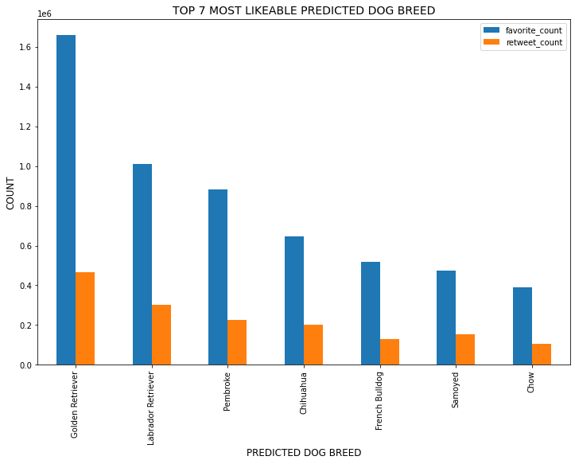

```python
# plot the vertical bar chart of the 7 highest breed using .plot method
liked_breed[:7].plot(kind='bar',figsize=(12,8))
plt.title('TOP 7 MOST LIKEABLE PREDICTED DOG BREED',fontsize=14)
plt.ylabel('COUNT',fontsize=12)
plt.xlabel('PREDICTED DOG BREED',fontsize=12);
```

The Golden Retriever is the most likeable dog breed. it has the highest favourite count and retweet count. People liked the pictures of a Golden Retriever more than other breeds,hence,more retweets.this is can be due to certain characteristics of the breed such as their friendliness, tolerant attitude that makes them great family pets, and their intelligence makes them highly capable working dogs. The second dog breed on the list of the most likeable breed is the Labrador Retriever. Therefore, we can conclude that people tends to love the Retriever breed more based on their characteristics.

Other breeds in the top 7 most likeable breed list are the Pembroke, the Chihuahua, the French Bulldog, the Samoyed and the Chow in descending order of likeness.

```python
# 2.Which dog name is the most common name?

# use the value count method to find out the name with highest entry value
liked_name=twitter_archive_master.dog_name.value_counts()
liked_name.head(10)
```

```
Cooper     9
Tucker     9
Penny      8
Lucy       8
Oliver     8
Daisy      7
Winston    7
Charlie    7
Toby       6
Jax        6
Name: dog_name, dtype: int64
```

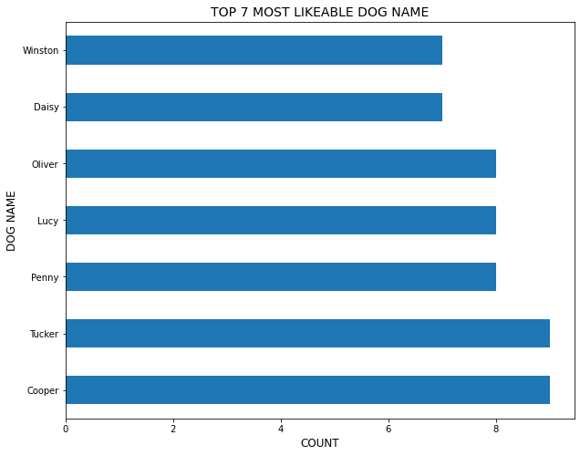

```python
# plot the horizontal bar chart of the 7 most common name using .plot method
liked_name[:7].plot(kind='barh',figsize=(10,8))
plt.title('TOP 7 MOST LIKEABLE DOG NAME',fontsize=14)
plt.xlabel('COUNT',fontsize=12)
plt.ylabel('DOG NAME',fontsize=12);
```

The most common or popular dog name among dog owners are Tucker and Cooper.

Other common dog names in the top 7 most likeable dog name list are Penny, Lucy, Oliver, Daisy, Winston in descending order.

```python
# install the necessary module to sort out the months and weekdays
pip install sorted-months-weekdays
```

```python
# instal the necessary module to sort out the dataframe months
pip install sort-dataframeby-monthorweek
```

```python
# to sort out weekdays and months,import the necessary libraries
from sorted_months_weekdays import *

from sort_dataframeby_monthorweek import *
```

```python
#3. What is the user_performance of the user of the WeRate Dog twitter account within the 3 years in the dataset?

# split the timestamp to get the month and year column using dt method
twitter_archive_master['year']=twitter_archive_master['timestamp'].dt.year
twitter_archive_master['month']=twitter_archive_master['timestamp'].dt.month
twitter_archive_master['month']= twitter_archive_master['month'].map({1:'Jan',2:'Feb',3:'Mar',4:'Apr',5:'May',6:'June',7:'July', 8:'Aug',9:'Sept',10:'Oct',11:'Nov',12:'Dec'})

#group the month and year according to the tweet count
user_performance=twitter_archive_master.groupby(['year','month']).agg(tweet_number=('tweet_id','count'))
user_performance
```

| year | month | tweet_number |
| --- | --- | --- |
| 2015 | Dec | 288 |
|  | Nov | 226 |
| 2016 | Apr | 50 |
|  | Aug | 46 |
|  | Dec | 52 |
|  | Feb | 1 |
|  | Jan | 131 |
|  | July | 76 |
|  | June | 69 |
|  | Mar | 107 |
|  | May | 48 |
|  | Nov | 45 |
|  | Oct | 60 |
|  | Sept | 56 |
| 2017 | Apr | 34 |
|  | Aug | 1 |
|  | Feb | 59 |
|  | Jan | 59 |
|  | July | 46 |
|  | June | 40 |
|  | Mar | 42 |
|  | May | 36 |

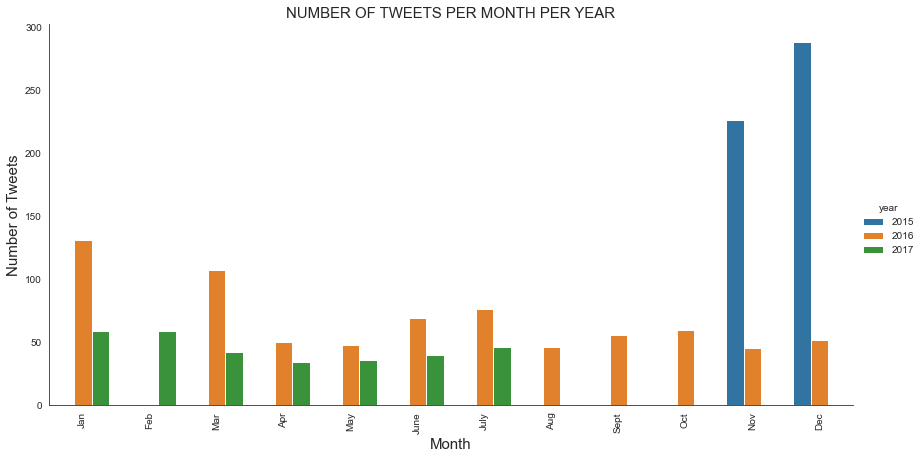

```python
# use seaborn to create a multivariate bar chart
plt.figure(figsize=(10,8))
sns.set_style('white')
month_order=['Jan','Feb','Mar','Apr','May','June','July','Aug','Sept','Oct','Nov','Dec']
sns.catplot(data=twitter_archive_master,x='month',hue='year',order=month_order,kind='count',height=6,aspect=2)
plt.xticks(rotation=90)
plt.xlabel('Month',fontsize=15)
plt.ylabel('Number of Tweets',fontsize=15)
plt.title('NUMBER OF TWEETS PER MONTH PER YEAR',fontsize=15);
```

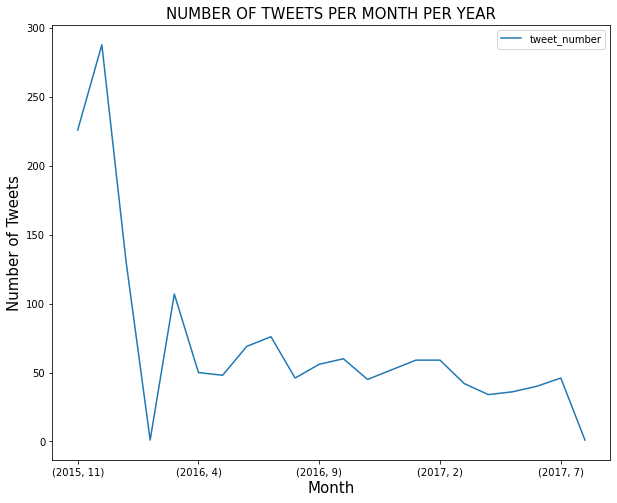

```python
# use line plot to show better visualization
user_performance.plot(figsize=(10,8))
plt.xlabel('Month',fontsize=15)
plt.ylabel('Number of Tweets',fontsize=15)
plt.title('NUMBER OF TWEETS PER MONTH PER YEAR',fontsize=15);
```

### CORRELATION BETWEEN VARIABLES

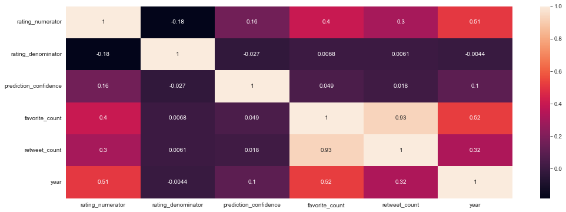

```python
#use seaborn to plot the correlation between each column
plt.figure(figsize=(17,6))
sns.heatmap(twitter_archive_master.corr(),annot=True)
```

The correlation coefficients in the heatmap above are indicators of the strength of the linear relationship between two different variables, x and y. A correlation of -1.0 indicates a perfect negative correlation, and a correlation of 1.0 indicates a perfect positive correlation. If the correlation coefficient is greater than zero, it is a positive relationship. Conversely, if the value is less than zero, it is a negative relationship. A value of zero indicates no relationship between the two variables x and y.

# CONCLUSION

The data wrangling process was carried out to produce a clean dataset despite the various challenges experienced. The analysis and visualization helps to have a clearer view of the dataset. We were able to know the type of breed people love the most and the likely names people give their dogs and many other insights.

One of the limitations encountered was during the gathering process, when requesting for access to Twitter API, the process took a lot of time and while getting the tweets ,some failed in the process therefore the table created from that data has records not up to the number of records in the archive.